# Case Study: Impact of Storms (and other severe weather events)

Shivangi

8/1/2020

## Synopsis

The basic goal of this study is to explore the NOAA Storm Database and answer some basic questions about severe weather events.  
Storms and other severe weather events can cause both public health and economic problems for communities and municipalities. Many severe events can result in fatalities, injuries, and property damage, and preventing such outcomes to the extent possible is a key concern.

## Data Processing

### Download the file from the web.

```r
setwd("C:/Users/comp/Documents/CourseraR/Reproducible Research/Case Study week 4")
url <- "https://d396qusza40orc.cloudfront.net/repdata%2Fdata%2FStormData.csv.bz2"
if(!file.exists("repdata_data_StormData.csv")){
download.file(url,destfile="repdata_data_StormData.csv")
}
```

The zip file containing dataset is downloaded from the link provided.  
Now we need to unzip the file into our working directory.

```r
data <- read.csv(bzfile("repdata_data_StormData.csv.bz2"),header = TRUE)
```

The storm data is loaded into the variable **data**.

### Examining the data.

```r
dim(data)
```

```
## [1] 902297     37
```

```r
names(data)
```

```
##  [1] "STATE__"    "BGN_DATE"   "BGN_TIME"   "TIME_ZONE"  "COUNTY"
##  [6] "COUNTYNAME" "STATE"      "EVTYPE"     "BGN_RANGE"  "BGN_AZI"
## [11] "BGN_LOCATI" "END_DATE"   "END_TIME"   "COUNTY_END" "COUNTYENDN"
## [16] "END_RANGE"  "END_AZI"    "END_LOCATI" "LENGTH"     "WIDTH"
## [21] "F"          "MAG"        "FATALITIES" "INJURIES"   "PROPDMG"
## [26] "PROPDMGEXP" "CROPDMG"    "CROPDMGEXP" "WFO"        "STATEOFFIC"
## [31] "ZONENAMES"  "LATITUDE"   "LONGITUDE"  "LATITUDE_E" "LONGITUDE_"
## [36] "REMARKS"    "REFNUM"
```

We have the dimensions and names of columns for the storm data. We need to extract those variables that will be suitable fro this analysis which are health and economic variables along with event types.

### Extracting variables of interest for analysis of weather impact on health and economy

From a list of variables in storm.data, these are columns of interest:

Health variables:  
* FATALITIES: approx. number of deaths  
* INJURIES: approx. number of injuries

Economic variables:

PROPDMG: approx. property damags  
PROPDMGEXP: the units for property damage value  
CROPDMG: approx. crop damages  
CROPDMGEXP: the units for crop damage value

Events - target variable:

EVTYPE: weather event (Tornados, Wind, Snow, Flood, etc..)

Loading the appropriate libraries:

```r
library(dplyr)
```

Extract variables of interest from original data set:

```r
vars <- data %>% select(EVTYPE, FATALITIES,INJURIES,PROPDMG,PROPDMGEXP,CROPDMG,CROPDMGEXP)
head(vars)
```

```
##    EVTYPE FATALITIES INJURIES PROPDMG PROPDMGEXP CROPDMG CROPDMGEXP
## 1 TORNADO          0       15    25.0          K       0
## 2 TORNADO          0        0     2.5          K       0
## 3 TORNADO          0        2    25.0          K       0
## 4 TORNADO          0        2     2.5          K       0
## 5 TORNADO          0        2     2.5          K       0
## 6 TORNADO          0        6     2.5          K       0
```

The selected columns are in the variable **vars**.

### Checking for missing values

```r
colSums(is.na(vars))
```

```
##     EVTYPE FATALITIES   INJURIES    PROPDMG PROPDMGEXP    CROPDMG CROPDMGEXP
##          0          0          0          0          0          0          0
```

Here, we can observe that there are no missing values in any of the columns.

### Transforming extracted variables

Listing the first 10 event types that most appear in the data:

```r
sort(table(vars$EVTYPE), decreasing = TRUE)[1:10]
```

```
##
##               HAIL          TSTM WIND  THUNDERSTORM WIND            TORNADO
##             288661             219940              82563              60652
##        FLASH FLOOD              FLOOD THUNDERSTORM WINDS          HIGH WIND
##              54277              25326              20843              20212
##          LIGHTNING         HEAVY SNOW
##              15754              15708
```

```r
vars$EVENT <- "OTHERS"
vars$EVENT[grep("TORNADO",vars$EVTYPE)]<-"TORNADO"
vars$EVENT[grep("WIND",vars$EVTYPE)]<-"WIND"
vars$EVENT[grep("FLOOD",vars$EVTYPE)]<-"FLOOD"
vars$EVENT[grep("STORM",vars$EVTYPE)]<-"STORM"
vars$EVENT[grep("RAIN",vars$EVTYPE)]<-"RAIN"
vars$EVENT[grep("SNOW",vars$EVTYPE)]<-"SNOW"
vars$EVENT[grep("HAIL",vars$EVTYPE)]<-"HAIL"
vars$EVENT[grep("HEAT",vars$EVTYPE)]<-"HEAT"
vars$EVENT[grep("LIGHTNING",vars$EVTYPE)]<-"LIGHTNING"
vars$EVENT[grep("WINTER",vars$EVTYPE)]<-"WINTER"
vars$EVENT[grep("FIRE",vars$EVTYPE)]<-"FIRE"
vars$EVENT[grep("DROUGHT",vars$EVTYPE)]<-"DROUGHT"
vars$EVENT[grep("FOG",vars$EVTYPE)]<-"FOG"

##  MAKING A TABLE OF EVENTS TO SEE THEIR RECURRENCE
sort(table(vars$EVENT),decreasing = TRUE)
```

```
##
##      HAIL      WIND     STORM     FLOOD   TORNADO    OTHERS    WINTER      SNOW
##    290394    254274    113046     82623     60699     24877     19582     17609
## LIGHTNING      RAIN      FIRE      HEAT   DROUGHT       FOG
##     15775     12158      4240      2628      2512      1880
```

Visualising the table for property damage expenses and crop damage expenses.

```r
sort(table(vars$PROPDMGEXP),decreasing=T)[1:10]
```

```
##
##             K      M      0      B      5      1      2      ?      m
## 465934 424665  11330    216     40     28     25     13      8      7
```

```r
sort(table(vars$CROPDMGEXP),decreasing=T)[1:10]
```

```
##
##             K      M      k      0      B      ?      2      m   <NA>
## 618413 281832   1994     21     19      9      7      1      1
```

New variable(s) is product of value of damage and dollar unit.

```r
vars$PROPDMGEXP[!grepl("K|M|B",vars$PROPDMGEXP)] <- 0
vars$PROPDMGEXP[grep("K", vars$PROPDMGEXP, ignore.case = TRUE)] <- "3"
vars$PROPDMGEXP[grep("M", vars$PROPDMGEXP, ignore.case = TRUE)] <- "6"
vars$PROPDMGEXP[grep("B", vars$PROPDMGEXP, ignore.case = TRUE)] <- "9"
class(vars$PROPDMGEXP)
```

```
## [1] "character"
```

```r
vars$PROPDMGEXP <- as.numeric(vars$PROPDMGEXP)
vars$property_damage <- vars$PROPDMG * 10^vars$PROPDMGEXP
```

We found the property damage expenses and stored the result in the column **property_damange**.  
Doing the same for to find the crop damage expenses.

```r
vars$CROPDMGEXP[!grepl("K|M|B",vars$CROPDMGEXP)] <- 0
vars$CROPDMGEXP[grep("K", vars$CROPDMGEXP, ignore.case = TRUE)] <- "3"
vars$CROPDMGEXP[grep("M", vars$CROPDMGEXP, ignore.case = TRUE)] <- "6"
vars$CROPDMGEXP[grep("B", vars$CROPDMGEXP, ignore.case = TRUE)] <- "9"
class(vars$CROPDMGEXP)
```

```
## [1] "character"
```

```r
vars$CROPDMGEXP <- as.numeric(vars$CROPDMGEXP)
vars$crop_damage <- vars$CROPDMG * 10^vars$CROPDMGEXP
```

```r
## printing first 10 values  of property_damage
sort(table(vars$property_damage),decreasing = TRUE)[1:10]
```

```
##
##      0   5000  10000   1000   2000  25000  50000   3000  20000  15000
## 663123  31731  21787  17544  17186  17104  13596  10364   9179   8617
```

```r
## printing first 10 value of crop_damage
sort(table(vars$crop_damage),decreasing = TRUE)[1:10]
```

```
##
##      0   5000  10000  50000  1e+05   2000   1000  25000  20000  5e+05
## 880198   4093   2347   1984   1233    951    946    830    758    721
```

## DATA ANALYSIS

### QUESTION STATEMENT:1

Across the United States, which types of events (as indicated in the EVTYPE variable) are most harmful with respect to population health?

```r
final_data <- vars %>% select(-c(EVTYPE))
ans_1 <- final_data %>% select(EVENT,FATALITIES,INJURIES) %>% group_by(EVENT) %>% summarize(FATAL_CASES= sum(FATALITIES),INJURED_CASES=sum(INJURIES), TOTAL_CASES=sum(FATALITIES+INJURIES))
ans_1
```

```
## # A tibble: 14 x 4
##    EVENT     FATAL_CASES INJURED_CASES TOTAL_CASES
##    <chr>           <dbl>         <dbl>       <dbl>
##  1 DROUGHT             6            19          25
##  2 FIRE               90          1608        1698
##  3 FLOOD            1522          8601       10123
##  4 FOG                81          1077        1158
##  5 HAIL               45          1467        1512
##  6 HEAT             3132          9139       12271
##  7 LIGHTNING         817          5232        6049
##  8 OTHERS           1647          4388        6035
##  9 RAIN              109           299         408
## 10 SNOW              167          1161        1328
## 11 STORM             416          5336        5752
## 12 TORNADO          5636         91407       97043
## 13 WIND             1199          8903       10102
## 14 WINTER            278          1891        2169
```

Exploratory Analysis of population health with respect to events.

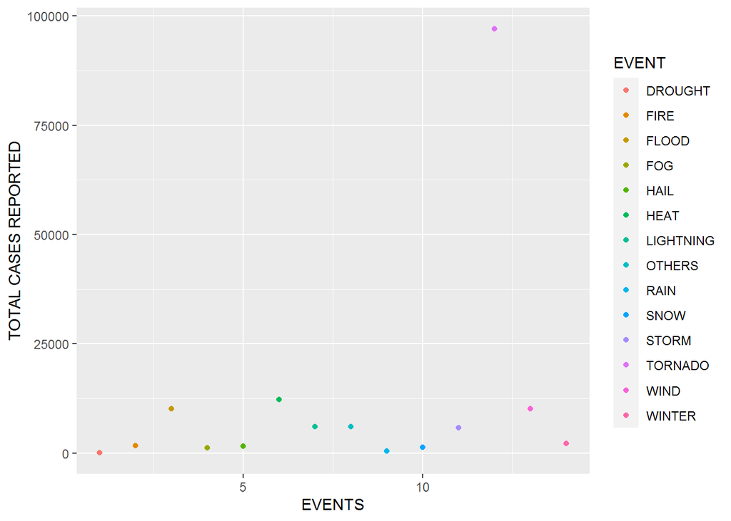

```r
library(ggplot2)
ans_1plot <- qplot(1:14,TOTAL_CASES,data=ans_1,col=EVENT)+labs(x="EVENTS",y="TOTAL CASES REPORTED")
print(ans_1plot)
```

Hence, it can be observed that TORNADO events are most harmful to population health.

### QUESTION STATEMENT: 2

Across the United States, which types of events have the greatest economic consequences?

```r
ans_2 <- final_data %>% select(EVENT,property_damage,crop_damage) %>% group_by(EVENT) %>% summarize(property_expenses= sum(property_damage),crop_expenses=sum(crop_damage), TOTAL_DAMAGE=sum(property_expenses+crop_expenses))
ans_2
```

```
## # A tibble: 14 x 4
##    EVENT     property_expenses crop_expenses  TOTAL_DAMAGE
##    <chr>                 <dbl>         <dbl>         <dbl>
##  1 DROUGHT         1046306000    13972621780  15018927780
##  2 FIRE            8501628500      403281630   8904910130
##  3 FLOOD         167356597930.   12238876110 179595474040.
##  4 FOG               25011500              0     25011500
##  5 HAIL           17615091077.    3113796290  20728887367.
##  6 HEAT              20125750      904413500    924539250
##  7 LIGHTNING        934007947.      12097090    946105037.
##  8 OTHERS         86891476910     9220461160  96111938070
##  9 RAIN            3243480192      917815800   4161295992
## 10 SNOW            1031474752.     134683100   1166157852.
## 11 STORM          66059568372.    6374336892  72433905264.
## 12 TORNADO        56981598040.     414961520  57396559560.
## 13 WIND           10796088118     1338967755  12135055873
## 14 WINTER          6777295251       47444000   6824739251
```

Exploratory data analysis of events with respect to economic consequences.

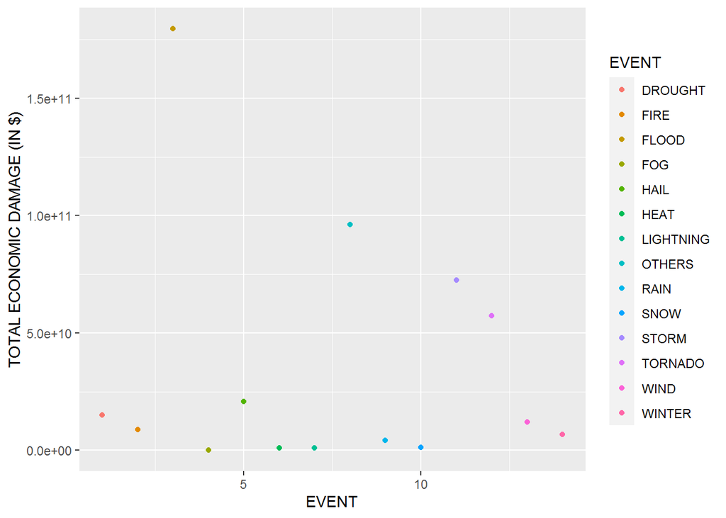

```r
ans_2plot <- qplot(1:14,TOTAL_DAMAGE,data=ans_2,col=EVENT)+labs(x="EVENT",y="TOTAL ECONOMIC DAMAGE (IN $)")
print(ans_2plot)
```

Hence, it can be observed that FLOOD events have the greatest economic consequences.

## RESULTS

### ANSWER STATEMENT: 1

The most harmful weather event for health (in number of total fatalites and injuries) is, by far, a tornado.

### ANSWER STATEMENT: 2

The most devastating weather event with the greatest economic cosequences (to property and crops) is a flood.